# Differential expression analysis of mouse somites - comparison of methods

29 May 2019

We have processed and QCed the RNA-seq from mouse somites. We then identified strong technical effects in the data, and thus used two different approaches to identify and remove such variation: surrogate variable analysis (SVA) and a PCA-based approach using the residuals of the fit of interest (combination of the somite and stage of each sample) to capture effects unrelated to this.

```r
meta <- read.table(paste0(dir, "RNA-seq/data/metadata_RNAseq.tsv"), stringsAsFactors = FALSE, header = TRUE)
meta <- meta[meta$use==1,]

data <- read.table(paste0(dir, "RNA-seq/data/geneCounts.RAW.tsv"))
y <- readRDS(paste0(dir, "RNA-seq/results/01_edgeRobject.Rds"))
```

We then performed differential expression analysis in three modes:

- **Baseline**: no control for any technical effects; this will probably have a lot of false positives and miss many true positives.
- **SVA approach**: control technical variation by blocking on the identified SVs.
- **PCA approach**: control technical variation by blocking on the identified PCs.

So let’s now compare the results from each.

#### Somite trios

First, we compare the somite I vs II vs III, which should identify the genes involved in triggering the differentiation program of somites after they are segmented.

We performed the test both on a stage-specific manner and taking the average across stages. To keep the comparisons simple, we will only focus on the averaged tests.

In all cases, we observed the most changes when comparing somites I and III, which are the most distinct. The number of genes detected was greater when using SVA compared to the baseline, and much higher with the PCA approach.

```r
## baseline
somiteTrios_base <- list()
somiteTrios_base[['IvsII']] <- read.table(paste0(dir, "RNA-seq/results/03.1_DEresults_somiteTrios_somiteIvsII.tsv"), stringsAsFactors = FALSE)
somiteTrios_base[['IIvsIII']] <- read.table(paste0(dir, "RNA-seq/results/03.1_DEresults_somiteTrios_somiteIIvsIII.tsv"), stringsAsFactors = FALSE)
somiteTrios_base[['IvsIII']] <- read.table(paste0(dir, "RNA-seq/results/03.1_DEresults_somiteTrios_somiteIvsIII.tsv"), stringsAsFactors = FALSE)

somiteTrios_base[["IvsII"]] <- somiteTrios_base[["IvsII"]][somiteTrios_base[["IvsII"]]$FDR < 0.05,]
somiteTrios_base[["IIvsIII"]] <- somiteTrios_base[["IIvsIII"]][somiteTrios_base[["IIvsIII"]]$FDR < 0.05,]
somiteTrios_base[["IvsIII"]] <- somiteTrios_base[["IvsIII"]][somiteTrios_base[["IvsIII"]]$FDR < 0.05,]

## SVA
somiteTrios_sva <- list()
somiteTrios_sva[['IvsII']] <- read.table(paste0(dir, "RNA-seq/results/03.2_DEresults_somiteTrios_somiteIvsII_sva.tsv"), stringsAsFactors = FALSE)
somiteTrios_sva[['IIvsIII']] <- read.table(paste0(dir, "RNA-seq/results/03.2_DEresults_somiteTrios_somiteIIvsIII_sva.tsv"), stringsAsFactors = FALSE)
somiteTrios_sva[['IvsIII']] <- read.table(paste0(dir, "RNA-seq/results/03.2_DEresults_somiteTrios_somiteIvsIII_sva.tsv"), stringsAsFactors = FALSE)

somiteTrios_sva[["IvsII"]] <- somiteTrios_sva[["IvsII"]][somiteTrios_sva[["IvsII"]]$FDR < 0.05,]
somiteTrios_sva[["IIvsIII"]] <- somiteTrios_sva[["IIvsIII"]][somiteTrios_sva[["IIvsIII"]]$FDR < 0.05,]
somiteTrios_sva[["IvsIII"]] <- somiteTrios_sva[["IvsIII"]][somiteTrios_sva[["IvsIII"]]$FDR < 0.05,]

## PCA
somiteTrios_pca <- list()
somiteTrios_pca[['IvsII']] <- read.table(paste0(dir, "RNA-seq/results/03.3_DEresults_somiteTrios_somiteIvsII_pca.tsv"), stringsAsFactors = FALSE)
somiteTrios_pca[['IIvsIII']] <- read.table(paste0(dir, "RNA-seq/results/03.3_DEresults_somiteTrios_somiteIIvsIII_pca.tsv"), stringsAsFactors = FALSE)
somiteTrios_pca[['IvsIII']] <- read.table(paste0(dir, "RNA-seq/results/03.3_DEresults_somiteTrios_somiteIvsIII_pca.tsv"), stringsAsFactors = FALSE)

somiteTrios_pca[["IvsII"]] <- somiteTrios_pca[["IvsII"]][somiteTrios_pca[["IvsII"]]$FDR < 0.05,]
somiteTrios_pca[["IIvsIII"]] <- somiteTrios_pca[["IIvsIII"]][somiteTrios_pca[["IIvsIII"]]$FDR < 0.05,]
somiteTrios_pca[["IvsIII"]] <- somiteTrios_pca[["IvsIII"]][somiteTrios_pca[["IvsIII"]]$FDR < 0.05,]

nDE <- data.frame(unlist(lapply(somiteTrios_base, nrow)), unlist(lapply(somiteTrios_sva, nrow)), unlist(lapply(somiteTrios_pca, nrow)))
colnames(nDE) <- c("baseline", "SVA", "PCA")
nDE
```

```
##         baseline SVA  PCA
## IvsII         95 408  731
## IIvsIII        3   0 2714
## IvsIII       700 860 4169
```

Considering the somite I vs III comparison, the majority of the genes called with the base and SVA methods are a subset of the PCA approach. Overall, the results agree well.

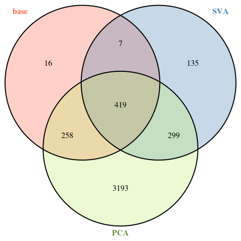

```r
v <- venn.diagram(x=list(base=somiteTrios_base[['IvsIII']]$genes, SVA=somiteTrios_sva[['IvsIII']]$genes, PCA=somiteTrios_pca[['IvsIII']]$genes), fill=c("tomato1", "steelblue", "darkolivegreen2"), cat.col=c("tomato1", "steelblue", "darkolivegreen4"), alpha = 0.3, cat.fontface=2, filename = NULL)
grid.draw(v)
```

The genes identified only with the SVA method tend to have much higher FDRs. For the PCA-specific genes, there is a similar distribution of FDR values, with many more showing very small values. The comparison is more difficult given how large is the number of genes that are PCA-specific.

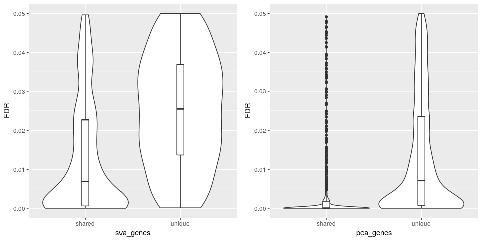

```r
plots <- list()

shared <- somiteTrios_sva[["IvsIII"]][somiteTrios_sva[["IvsIII"]]$genes %in% intersect(somiteTrios_sva[["IvsIII"]]$genes, somiteTrios_pca[["IvsIII"]]$genes),]
sva_only <- somiteTrios_sva[["IvsIII"]][somiteTrios_sva[["IvsIII"]]$genes %in% setdiff(somiteTrios_sva[["IvsIII"]]$genes, somiteTrios_pca[["IvsIII"]]$genes),]

df <- data.frame(FDR = c(shared$FDR, sva_only$FDR), sva_genes=c(rep("shared", nrow(shared)), rep("unique", nrow(sva_only))))
plots[[1]] <- ggplot(df, aes(sva_genes, FDR)) + geom_violin(scale="width") + geom_boxplot(width=0.075)


shared <- somiteTrios_pca[["IvsIII"]][somiteTrios_pca[["IvsIII"]]$genes %in% intersect(somiteTrios_sva[["IvsIII"]]$genes, somiteTrios_pca[["IvsIII"]]$genes),]
pca_only <- somiteTrios_pca[["IvsIII"]][somiteTrios_pca[["IvsIII"]]$genes %in% setdiff(somiteTrios_pca[["IvsIII"]]$genes, somiteTrios_sva[["IvsIII"]]$genes),]

df <- data.frame(FDR = c(shared$FDR, pca_only$FDR), pca_genes=c(rep("shared", nrow(shared)), rep("unique", nrow(pca_only))))
plots[[2]] <- ggplot(df, aes(pca_genes, FDR)) + geom_violin(scale="width") + geom_boxplot(width=0.075)

multiplot(plotlist = plots, cols=2)
```

Thus, this suggests that the genes lost from the SVA method are weak candidates, so not a bit loss.

The question now is whether the over 3 thousand genes recovered by the PCA approach are indeed DE.

From the MA plot we can see that many of the fold-changes are very small.

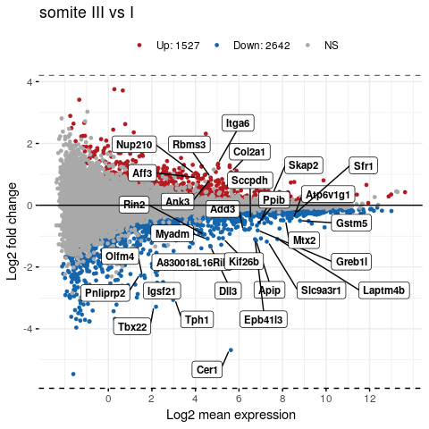

```r
tmp <- read.table(paste0(dir, "RNA-seq/results/03.3_DEresults_somiteTrios_somiteIvsIII_pca.tsv"), stringsAsFactors = FALSE)
colnames(tmp)[c(2,3,6)] <- c("log2FoldChange","baseMean","padj")
tmp$baseMean <- 2^tmp$baseMean-1
ggmaplot(tmp, FDR = 0.05, fc=0, genenames = tmp$genes, size=1, legend = "top", top=30, label.rectangle = TRUE, select.top.method = "padj", font.label = c("bold", 9), main="somite III vs I ", ggtheme = theme_minimal() )
```

Indeed, a large portion of the genes show a log2-fold-change of only 0.2 (dashed lines). This corresponds to a fold-change of 1.15 which is not really meaningful. This suggests that by removing all the structure found in the residuals of the fit we have reduced the noise to a point where we have ridiculous power to *detect tiny differences*, but these probably are not differences we are interested in. So we can add a filter requiring a fold-change of at least 1.5 (dotted lines) to retain only substantial changes.

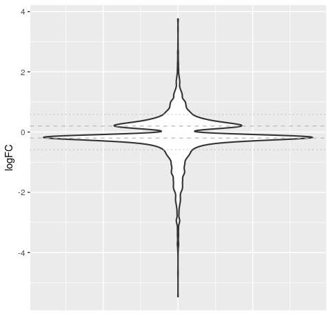

```r
ggplot(somiteTrios_pca[["IvsIII"]], aes(1,logFC)) + geom_violin(lwd=0.75) + geom_hline(yintercept=c(-log2(1.5),-0.2,0.2,log2(1.5)), lty=c(3,2,2,3), col="grey") + xlab("") + theme(axis.ticks.x = element_blank(), axis.text.x = element_blank())
```

This filter affects much more the results from the PCA analysis, followed by the SVA results and filters the fewest genes from the baseline results. This agrees with increases in power gained by reducing the dataset’s variability.

```r
somiteTrios_base.filter <- somiteTrios_base
somiteTrios_base.filter <- lapply(somiteTrios_base.filter, function(x) x[abs(x$logFC) > log2(1.5),])

somiteTrios_sva.filter <- somiteTrios_sva
somiteTrios_sva.filter <- lapply(somiteTrios_sva.filter, function(x) x[abs(x$logFC) > log2(1.5),])

somiteTrios_pca.filter <- somiteTrios_pca
somiteTrios_pca.filter <- lapply(somiteTrios_pca.filter, function(x) x[abs(x$logFC) > log2(1.5),])

nDE <- cbind(nDE, data.frame(unlist(lapply(somiteTrios_base.filter, nrow)), unlist(lapply(somiteTrios_sva.filter, nrow)), unlist(lapply(somiteTrios_pca.filter, nrow))))
colnames(nDE)[-c(1:3)] <- paste0(colnames(nDE)[1:3], ">1.5")
nDE
```

```
##         baseline SVA  PCA baseline>1.5 SVA>1.5 PCA>1.5
## IvsII         95 408  731           80     169     294
## IIvsIII        3   0 2714            2       0     442
## IvsIII       700 860 4169          449     357    1020
```

After applying the minimum fold-change requirement, there are still many more genes identified with the PCA method. And now the results form the three analyses agree even better, with the vast majority of genes from the baseline and SVA tests identified in the PCA analysis also.

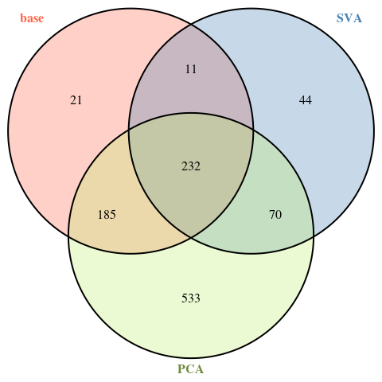

```r
v <- venn.diagram(x=list(base=somiteTrios_base.filter[['IvsIII']]$genes, SVA=somiteTrios_sva.filter[['IvsIII']]$genes, PCA=somiteTrios_pca.filter[['IvsIII']]$genes), fill=c("tomato1", "steelblue", "darkolivegreen2"), cat.col=c("tomato1", "steelblue", "darkolivegreen4"), alpha = 0.3, cat.fontface=2, filename = NULL)
grid.draw(v)
```

So let’s check the genes gained from the PCA method. As before, they have a similar distribution of p-values to those shared with the other methods, but they do tend to have smaller fold-changes, suggesting we gain them due to the increased power in the test.

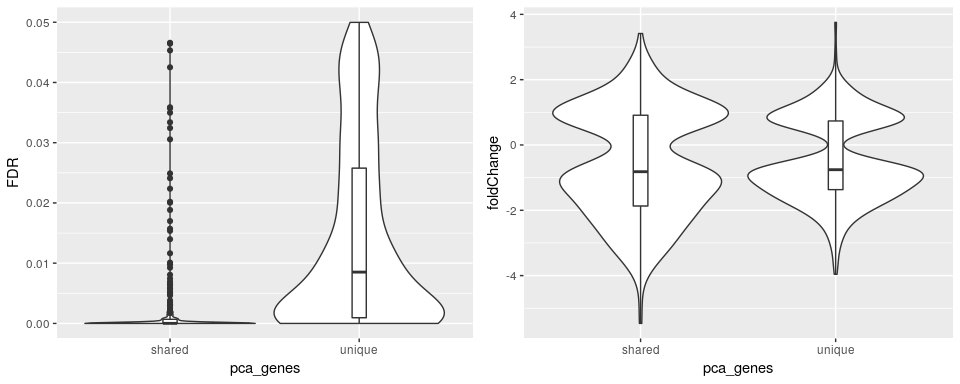

```r
plots <- list()
shared <- somiteTrios_pca.filter[["IvsIII"]][somiteTrios_pca.filter[["IvsIII"]]$genes %in% intersect(somiteTrios_sva.filter[["IvsIII"]]$genes, somiteTrios_pca.filter[["IvsIII"]]$genes),]
pca_only <- somiteTrios_pca.filter[["IvsIII"]][somiteTrios_pca.filter[["IvsIII"]]$genes %in% setdiff(somiteTrios_pca.filter[["IvsIII"]]$genes, somiteTrios_sva.filter[["IvsIII"]]$genes),]

df <- data.frame(FDR = c(shared$FDR, pca_only$FDR), pca_genes=c(rep("shared", nrow(shared)), rep("unique", nrow(pca_only))))
plots[[1]] <- ggplot(df, aes(pca_genes, FDR)) + geom_violin(scale="width") + geom_boxplot(width=0.075)

df <- data.frame(foldChange = c(shared$logFC, pca_only$logFC), pca_genes=c(rep("shared", nrow(shared)), rep("unique", nrow(pca_only))))
plots[[2]] <- ggplot(df, aes(pca_genes, foldChange)) + geom_violin(scale="width") + geom_boxplot(width=0.075)

multiplot(plotlist = plots, cols=2)
```

To convince ourselves that we are picking up sensible changes, we take genes from all levels of significance, that have only been identified with the PCA method.

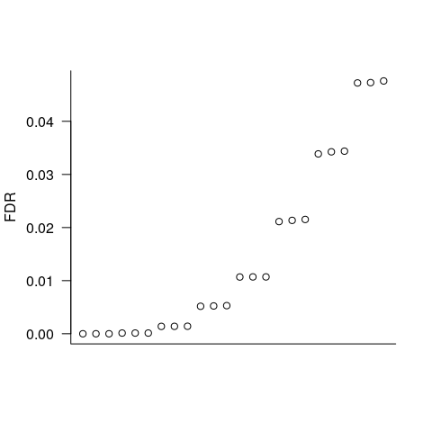

```r
plot(pca_only[c(1:3,101:103,201:203,301:303,401:403,501:503,601:603,701:703),]$FDR, xlab="", ylab="FDR", axes=FALSE)
box(bty="l"); axis(2, las=2)
```

And we plot their expression levels in each somite, using baseline counts (that is, only normalised for depth of sequencing and composition biases, without removing the technical effects).

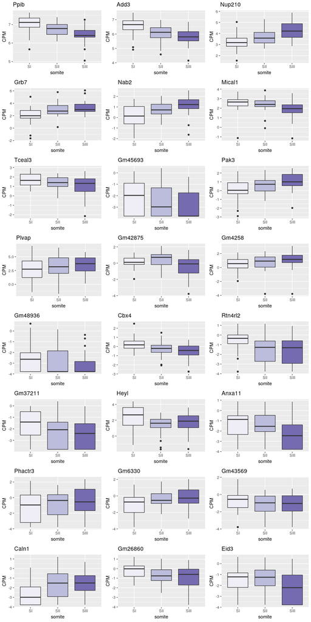

```r
dataNorm <- cpm(y$counts, log=TRUE, prior.count = 1)
dataNorm <- cbind(data[match(row.names(dataNorm), row.names(data)),1], as.data.frame(dataNorm))
colnames(dataNorm)[1] <- "gene"
# dataNorm <- removeBatchEffect(dataNorm[,-1], design = model.matrix(~0+group, meta), covariates = pcs[,1:14])
# dataNorm <- cbind(data[match(row.names(dataNorm), row.names(data)),1], as.data.frame(dataNorm)); colnames(dataNorm)[1] <- "gene"

retrieveGeneExpr <- function(dataNorm, meta, columns=c("stage", "somite", "date"), gene){
  d <- t(as.data.frame(dataNorm[dataNorm$gene==gene,-1]))
  stopifnot(identical(row.names(d), meta$sample))
  d <- cbind(d, meta[,columns])
  colnames(d)[1] <- "count"
  return(d)
}

plots <- list()
j=1
for(i in pca_only$genes[c(1:3,101:103,201:203,301:303,401:403,501:503,601:603,701:703)]){
  d <- retrieveGeneExpr(dataNorm, meta, gene=i)
  plots[[j]] <- ggplot(d, aes(x=somite, y=count)) + geom_boxplot(aes(fill=somite)) + scale_fill_brewer(palette = "Purples") + ggtitle(i) + theme(legend.position="none") + ylab("CPM")
  j <- j+1
}
multiplot(plotlist = plots, cols=3)
```

Even the genes that have p-values close to 0.05 (last three) show clear dynamics across somites, even if the changes are quite subtle. Such differences will become more pronounced if the technical variation is regressed out:

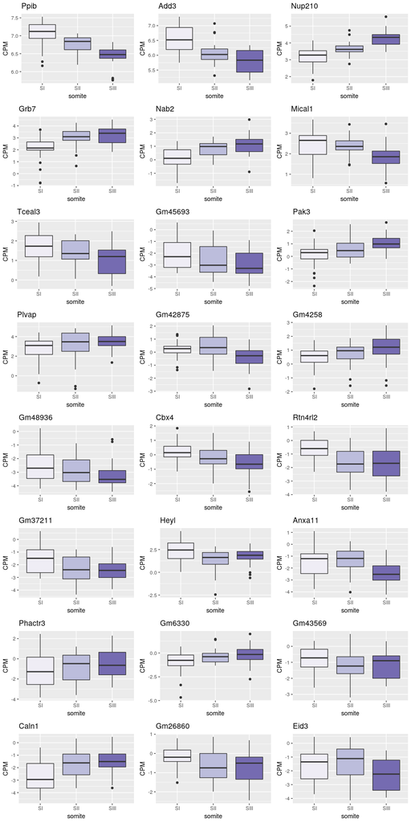

```r
pcs <- read.table(paste0(dir, "RNA-seq/results/02_pcs_residuals.tab"))
dataNorm.corr <- removeBatchEffect(dataNorm[,-1], design = model.matrix(~0+group, meta), covariates = pcs[,1:14])
dataNorm.corr <- cbind(data[match(row.names(dataNorm.corr), row.names(data)),1], as.data.frame(dataNorm.corr)); colnames(dataNorm.corr)[1] <- "gene"

plots <- list()
j=1
for(i in pca_only$genes[c(1:3,101:103,201:203,301:303,401:403,501:503,601:603,701:703)]){
  d <- retrieveGeneExpr(dataNorm.corr, meta, gene=i)
  plots[[j]] <- ggplot(d, aes(x=somite, y=count)) + geom_boxplot(aes(fill=somite)) + scale_fill_brewer(palette = "Purples") + ggtitle(i) + theme(legend.position="none") + ylab("CPM")
  j <- j+1
}
multiplot(plotlist = plots, cols=3)
```

So this all seems sensible, and the gained genes do seem to be DE between somites.

#### Developmental changes

So now let’s do the same for the tests looking at changes across developmental stages.

```r
stages_base <- read.table(paste0(dir, "RNA-seq/results/03.1_DEresults_stage_all.tsv"), stringsAsFactors = FALSE)
stages_sva <- read.table(paste0(dir, "RNA-seq/results/03.2_DEresults_stage_all_sva.tsv"), stringsAsFactors = FALSE)
stages_pca <- read.table(paste0(dir, "RNA-seq/results/03.3_DEresults_stage_all_pca.tsv"), stringsAsFactors = FALSE)

stages_base <- stages_base[stages_base$FDR < 0.05,]
stages_sva <- stages_sva[stages_sva$FDR < 0.05,]
stages_pca <- stages_pca[stages_pca$FDR < 0.05,]

nDE <- data.frame(baseline=nrow(stages_base), SVA=nrow(stages_sva), PCA=nrow(stages_pca))
row.names(nDE) <- "stageChanges"
nDE
```

```
##              baseline  SVA   PCA
## stageChanges     7843 2302 13500
```

Like before, the results from the baseline and SVA tests are pretty much subsets of the PCA set.

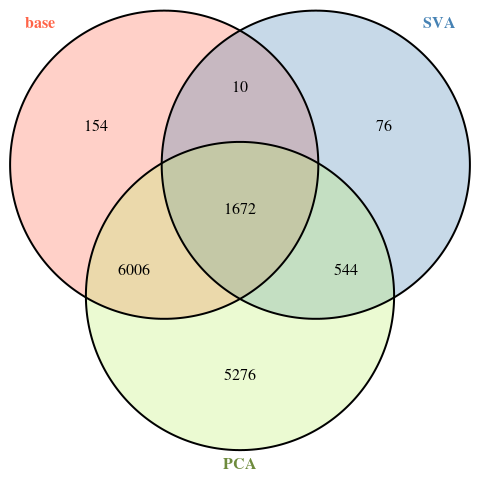

```r
v <- venn.diagram(x=list(base=stages_base$genes, SVA=stages_sva$genes, PCA=stages_pca$genes), fill=c("tomato1", "steelblue", "darkolivegreen2"), cat.col=c("tomato1", "steelblue", "darkolivegreen4"), alpha = 0.3, cat.fontface=2, filename = NULL)
grid.draw(v)
```

And the genes identified with only the baseline or SVA approach have quite high FDRs, while those unique to the PCA method have a similar distribution to the genes identified in all three tests.

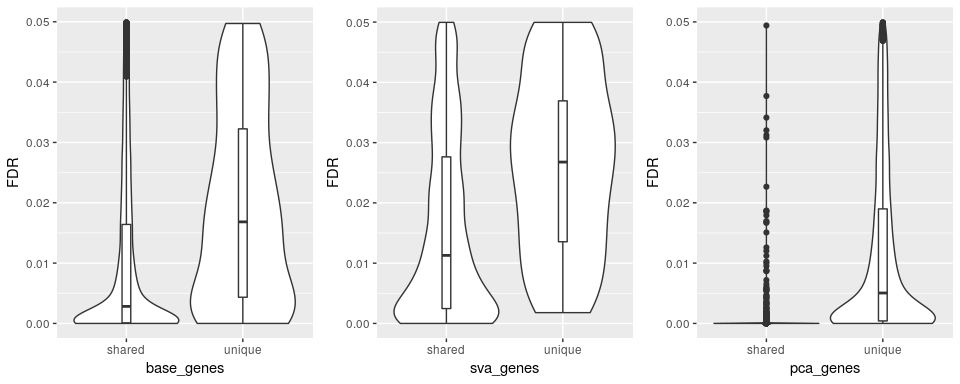

```r
plots <- list()

shared <- stages_base[stages_base$genes %in% intersect(stages_base$genes, stages_pca$genes),]
base_only <- stages_base[stages_base$genes %in% setdiff(stages_base$genes, stages_pca$genes),]

df <- data.frame(FDR = c(shared$FDR, base_only$FDR), base_genes=c(rep("shared", nrow(shared)), rep("unique", nrow(base_only))))
plots[[1]] <- ggplot(df, aes(base_genes, FDR)) + geom_violin(scale="width") + geom_boxplot(width=0.075)

shared <- stages_sva[stages_sva$genes %in% intersect(stages_sva$genes, stages_pca$genes),]
sva_only <- stages_sva[stages_sva$genes %in% setdiff(stages_sva$genes, stages_pca$genes),]

df <- data.frame(FDR = c(shared$FDR, sva_only$FDR), sva_genes=c(rep("shared", nrow(shared)), rep("unique", nrow(sva_only))))
plots[[2]] <- ggplot(df, aes(sva_genes, FDR)) + geom_violin(scale="width") + geom_boxplot(width=0.075)


shared <- stages_pca[stages_pca$genes %in% intersect(intersect(stages_sva$genes, stages_pca$genes), stages_base$genes),]
pca_only <- stages_pca[stages_pca$genes %in% setdiff(stages_pca$genes, union(stages_base$genes, stages_sva$genes)),]

df <- data.frame(FDR = c(shared$FDR, pca_only$FDR), pca_genes=c(rep("shared", nrow(shared)), rep("unique", nrow(pca_only))))
plots[[3]] <- ggplot(df, aes(pca_genes, FDR)) + geom_violin(scale="width") + geom_boxplot(width=0.075)

multiplot(plotlist = plots, cols=3)
```

As observed with the somite trio test, the fold-changes are dominated by very small changes, due to the increased power. The changes between stages are much larger, so now the bulk of the genes have fold-changes of about 1.3 (dashed line). This is still a very small difference and probably not very informative. The filter of minimum fold-change of 1.5 (dotted line) is quite close to the current peak.

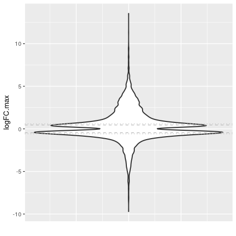

```r
## get the largest fold-change from all pairwise comparisons
stages_pca$logFC.max <- sapply(1:nrow(stages_pca), function(x) stages_pca[x,which.max(abs(stages_pca[x,2:16]))+1])

ggplot(stages_pca, aes(1,logFC.max)) + geom_violin(lwd=0.75) + geom_hline(yintercept=c(-log2(1.5),-0.45,0.45,log2(1.5)), lty=c(3,2,2,3), col="grey") + xlab("") + theme(axis.ticks.x = element_blank(), axis.text.x = element_blank())
```

But still, this filter reduces the number of DE genes by about half for the PCA method, and a bit less for the other methods, suggesting it effectively reduces the genes that became significant just due to massive power but are not real differences.

```r
stages_base$logFC.max <- sapply(1:nrow(stages_base), function(x) stages_base[x,which.max(abs(stages_base[x,2:16]))+1])
stages_sva$logFC.max <- sapply(1:nrow(stages_sva), function(x) stages_sva[x,which.max(abs(stages_sva[x,2:16]))+1])

stages_base.filter <- stages_base[abs(stages_base$logFC.max) > log2(1.5),]
stages_sva.filter <- stages_sva[abs(stages_sva$logFC.max) > log2(1.5),]
stages_pca.filter <- stages_pca[abs(stages_pca$logFC.max) > log2(1.5),]

nDE <- rbind(nDE, data.frame(baseline=nrow(stages_base.filter), SVA=nrow(stages_sva.filter), PCA=nrow(stages_pca.filter)))
row.names(nDE)[2] <- "FC>1.5"
nDE
```

```
##              baseline  SVA   PCA
## stageChanges     7843 2302 13500
## FC>1.5           5929 1577  7890
```

And this reduction results in less genes shared by several methods, with a corresponding increase in the number of genes detected only with the baseline or SVA approach. This indicates that some of the genes that are significant in several methods have fold-changes around the threshold and sometimes get filtered out and sometimes not.

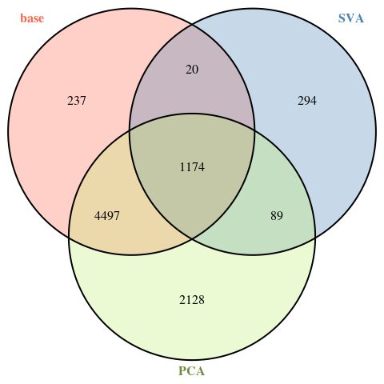

```r
v <- venn.diagram(x=list(base=stages_base.filter$genes, SVA=stages_sva.filter$genes, PCA=stages_pca.filter$genes), fill=c("tomato1", "steelblue", "darkolivegreen2"), cat.col=c("tomato1", "steelblue", "darkolivegreen4"), alpha = 0.3, cat.fontface=2, filename = NULL)
grid.draw(v)
```

Nonetheless, the remaining genes should include much more meaningful genes. So let’s check the gained genes from the PCA method. As before, the FDR distribution is similar to that of shared genes, but the unique tend to have slightly smaller fold-changes.

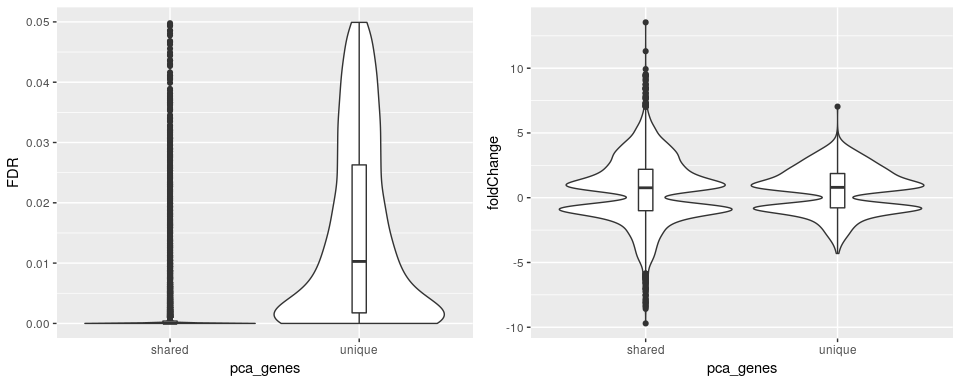

```r
plots <- list()
shared <- stages_pca.filter[stages_pca.filter$genes %in% intersect(stages_pca.filter$genes, union(stages_base.filter$genes, stages_sva.filter$genes)),]
pca_only <- stages_pca.filter[stages_pca.filter$genes %in% setdiff(stages_pca.filter$genes, union(stages_base.filter$genes, stages_sva.filter$genes)),]

df <- data.frame(FDR = c(shared$FDR, pca_only$FDR), pca_genes=c(rep("shared", nrow(shared)), rep("unique", nrow(pca_only))))
plots[[1]] <- ggplot(df, aes(pca_genes, FDR)) + geom_violin(scale="width") + geom_boxplot(width=0.075)

df <- data.frame(foldChange = c(shared$logFC.max, pca_only$logFC.max), pca_genes=c(rep("shared", nrow(shared)), rep("unique", nrow(pca_only))))
plots[[2]] <- ggplot(df, aes(pca_genes, foldChange)) + geom_violin(scale="width") + geom_boxplot(width=0.075)

multiplot(plotlist = plots, cols=2)
```

Some examples spanning the whole FDR range:

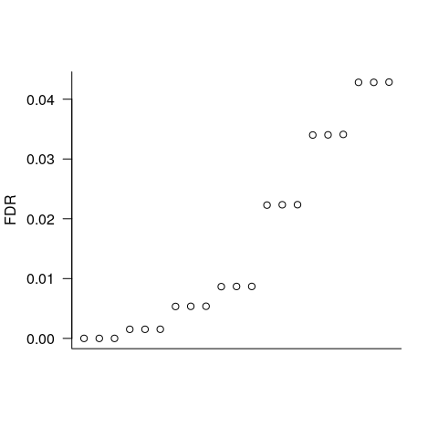

```r
plot(pca_only[c(1:3,501:503,801:803,1001:1003,1501:1503,1801:1803,2001:2003),]$FDR, xlab="", ylab="FDR", axes=FALSE)
box(bty="l"); axis(2, las=2)
```

When we plot their expression levels in each stage using baseline counts (that is, only normalised for depth of sequencing and composition biases, without removing the technical effects) the dynamics become less obvious as significance decreases, as expected.

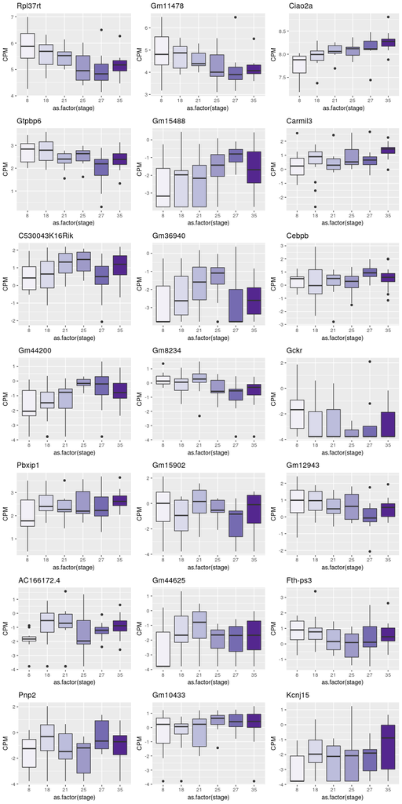

```r
plots <- list()
j=1

for(i in pca_only$genes[c(1:3,501:503,801:803,1001:1003,1501:1503,1801:1803,2001:2003)]){
  d <- retrieveGeneExpr(dataNorm, meta, gene=i)
  plots[[j]] <- ggplot(d, aes(x=as.factor(stage), y=count)) + geom_boxplot(aes(fill=as.factor(stage))) + scale_fill_brewer(palette = "Purples") + ggtitle(i) + theme(legend.position="none") + ylab("CPM")
  j <- j+1
}
multiplot(plotlist = plots, cols=3)
```

But once the technical variation is regressed out, the dynamics are evident even for the least significant genes, even if subtle.

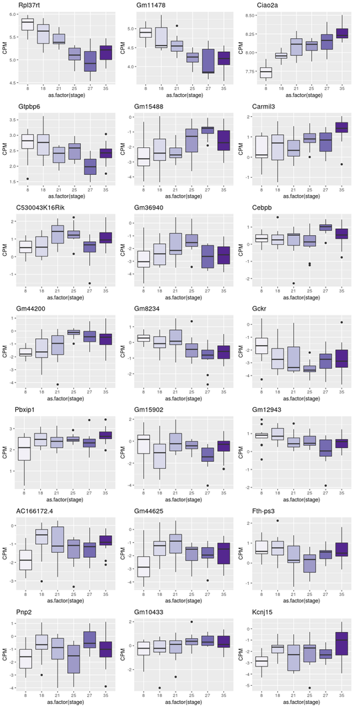

```r
plots <- list()
j=1
for(i in pca_only$genes[c(1:3,501:503,801:803,1001:1003,1501:1503,1801:1803,2001:2003)]){
  d <- retrieveGeneExpr(dataNorm.corr, meta, gene=i)
  plots[[j]] <- ggplot(d, aes(x=as.factor(stage), y=count)) + geom_boxplot(aes(fill=as.factor(stage))) + scale_fill_brewer(palette = "Purples") + ggtitle(i) + theme(legend.position="none") + ylab("CPM")
  j <- j+1
}
multiplot(plotlist = plots, cols=3)
```

#### Conclusions

So based on all these, we can conclude that using the PCA approach greatly increases our statistical power to identify DE genes. The increase is such that we identify genes that are not really that different between conditions, and so it is necessary to apply a minimum fold-change threshold to get sensible results.